# Fisseha Berhane, PhD

#### Data Scientist

443-970-2353 fisseha@jhu.edu CV Resume

### Numpy and Pandas to work with multidimensional arrays

The NumPy (Numeric Python) package provides basic routines for manipulating large arrays and matrices of numeric data.

Using Pandas in climate data analysis is a good habit because it provides fast, flexible, and expressive data structures and it is easy and intuitive to apply.

Here, I show the convenience of using numpy together with pandas and matplotlib in working with climate data. I am analysing sea surface temperature and near surface air temperature during the two phases of the ElNino- Southern Oscillation. I show composite analysis based on the sea surface temperature in the Eastern Tropical Pacific SST (5N-5S,150W-90W) from [NOAA Climate Prediction Center (CPC)](http://www.cpc.ncep.noaa.gov/data/indices/).

Load required packages

```python
import pandas as pd
import numpy as np
import matplotlib.pylab as plt
from pandas import Series
from mpl_toolkits.basemap import Basemap
from netCDF4 import Dataset as netcdf       # netcdf4-python module
from netCDF4 import num2date
```

```python
%matplotlib inline
```

Load datasets

The Nino 3 index is from [NOAA](http://www.esrl.noaa.gov/psd/data/climateindices/list/). The air temperature data are [NCEP-R1](http://www.esrl.noaa.gov/psd/data/gridded/data.ncep.reanalysis.html). The sea surface temperature (SST) data can be downloadef from [this](http://www.esrl.noaa.gov/psd/data/gridded/data.noaa.oisst.v2.html).

Loading Sea Surface temperature and getting the variables we need.

```python
a = netcdf( r'C:\Fish\Python\scripts\sst.mnmean2.v4.nc')
sst = a.variables['SST'][:]
time_sst = a.variables['TIME']
lon_sst = a.variables['LON'][:]
lat_sst = a.variables['LAT'][:]
```

Similarrly, let's load the air temperature data and get the values of air temperature and the dimensions.

```python
a = netcdf( r'C:\Fish\Python\scripts\air.mon.mean.nc')
air = a.variables['air'][:]
time_air = a.variables['time']
lon_air = a.variables['lon'][:]
lat_air = a.variables['lat'][:]
```

Let's create variables that contain $datetime$ values using $num2date$ function from $netCDF4$ package.

```python
dates_sst = num2date(time_sst[:], time_sst.units)
dates_air = num2date(time_air[:], time_air.units)
```

Now, let's convert them to pandas format and then convert timestamps to periods. Both datasets are at monthly resolution.

```python
dates_pd_sst = pd.to_datetime(dates_sst)
dates_pd_air = pd.to_datetime(dates_air)
```

```python
periods_sst = dates_pd_sst.to_period(freq='M')
periods_air = dates_pd_air.to_period(freq='M')
```

We can see when the datasets start and end:

```python
periods_sst[0],periods_air[0]
```

```
(Period('1854-01', 'M'), Period('1948-01', 'M'))
```

```python
periods_sst[-1],periods_air[-1]
```

```
(Period('2015-05', 'M'), Period('2015-04', 'M'))
```

Now, let's analyze the period from 1960-2010. Get the time period:

```python
a= (periods_air>=1960)&(periods_air.year<=2010)
```

Get the air temperature data over the specified period.

```python
air2=air[a,:,:]
```

Now, let's extract SST over the period we are interested in.

```python
a = (periods_sst.year>=1960)&(periods_sst.year<=2010)
sst2=sst[a,:,:]
```

See the dimensions of the datasets over the selected period.

```python
sst2.shape, air2.shape
```

```
((612L, 89L, 180L), (612L, 73L, 144L))
```

The Nino 3 index covers the period from 1950-01 to 2014-12. So, let's create a date range using pandas.

```python
nino=np.loadtxt(r'C:\Fish\Python\scripts\nina3.data')
nino=nino[:,1:]
nino=nino.flatten()
dates = pd.date_range('1950-01', '2015-01', freq='M')
nino = Series(nino, index=dates)
```

We also need Nino 3 index from 1960 to 2010.

```python
nino=nino['1960':'2010']
```

Let's standardize the index (subtract the mean and divide by the standard deviation) to use it for composite analysis.

```python
nino=(nino-nino.mean())/nino.std()
```

Let's check that the index has mean 0 and std of 1

```python
nino.mean(), nino.std()
```

```
(2.9025438552291676e-17, 1.0000000000000002)
```

```python
nino=np.array(nino)
```

Get SST during ElNino events.

```python
sst_elnino=sst2[nino>=1.5,:,:]
sst_elnino.shape
```

```
(32L, 89L, 180L)
```

Get SST during LaNina events.

```python
sst_lanina=sst2[nino<=-1.5,:,:]
sst_lanina.shape
```

```
(46L, 89L, 180L)
```

The function below is a helper function to plot the composites of SST during ElNino and LaNina.

```python
def sst_composite(sample):
    lons, lats = np.meshgrid(lon_sst, lat_sst)

    m = Basemap(projection='mill',llcrnrlat=-80,urcrnrlat=80,\
            llcrnrlon=0,urcrnrlon=360,lat_ts=20,resolution='c')
    x, y = m(lons, lats)
    plt.figure(figsize=(10,7))
    m.drawcoastlines()
    m.drawparallels(np.arange(-80.,81.,20.))
    m.drawmeridians(np.arange(-180.,181.,20.))
    m.drawmapboundary(fill_color='white')
    m.contourf(x,y,(sample.mean(axis=0)-sst2.mean(axis=0)),15,cmap=plt.cm.jet,vmin=-3, vmax=3,extend='both');
    plt.colorbar( orientation='horizontal', pad=0.05)
```

Now, let's see the SST pattern during ElNino.

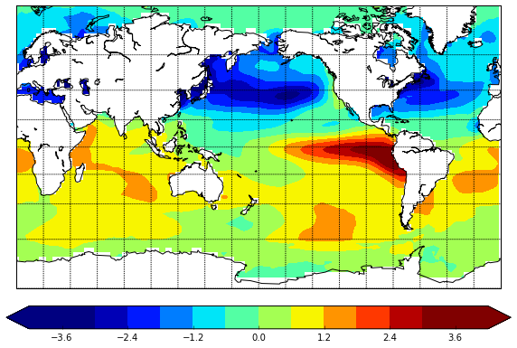

```python
sst_composite(sst_elnino)
```

There is warming in the eastern Pacific Ocean, as expected. We also see posetive PDO like structure and warming over the western Indian Ocean.

Now, let's see the pattern during Lanina.

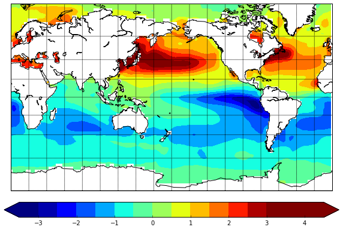

```python
sst_composite(sst_lanina)
```

In the same fashion, we can plot the composites of near surface temperature and scrutinize the patterns.

```python
air_elnino=air2[nino>=1.5,:,:]
air_elnino.shape
```

```
(32L, 73L, 144L)
```

```python
air_lanina=air2[nino<=-1.5,:,:]
air_lanina.shape
```

```
(46L, 73L, 144L)
```

A helper function for the composites:

```python
def air_composite(sample):
    lons, lats = np.meshgrid(lon_air, lat_air)

    m = Basemap(projection='mill',llcrnrlat=-80,urcrnrlat=80,\
            llcrnrlon=0,urcrnrlon=360,lat_ts=20,resolution='c')
    x, y = m(lons, lats)
    plt.figure(figsize=(10,7))
    m.drawcoastlines()
    m.drawparallels(np.arange(-80.,81.,20.))
    m.drawmeridians(np.arange(-180.,181.,20.))
    m.drawmapboundary(fill_color='white')
    m.contourf(x,y,(sample.mean(axis=0)-air2.mean(axis=0)),15,cmap=plt.cm.jet,vmin=-3, vmax=3,extend='both');
    plt.colorbar( orientation='horizontal', pad=0.05)
```

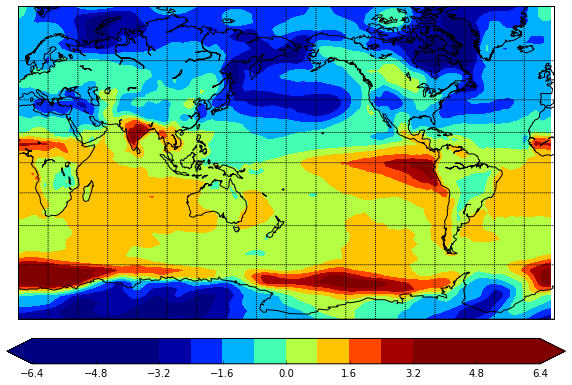

```python
air_composite(air_elnino)
```

We see that large parts of the northen hemisphere is colder during ElNino.

We can also see the temperature pattern during LaNina.

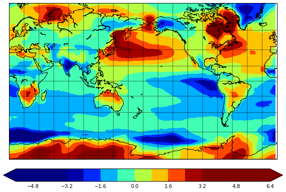

```python
air_composite(air_lanina)
```

[comments powered by Disqus](http://disqus.com)